# Reproducible Research Assignment

Carlos Ramirez

June 10, 2017

This report shows the analysis and processing of the data about steps activity by time intervals recorded during the day recorded in the period from october to november, 2012.

### **1. Reading in the dataset and/or processing the data**

```r
## reading the data
activity <- read.csv(unz("activity.zip","activity.csv"),
                     header = TRUE,
                     colClasses = c("numeric","character","numeric"))
activity <- transform(activity, date = as.Date(date))
```

### **2. Total number of steps taken each day**

The next plot shows the distribution of dairy steps in all the data.

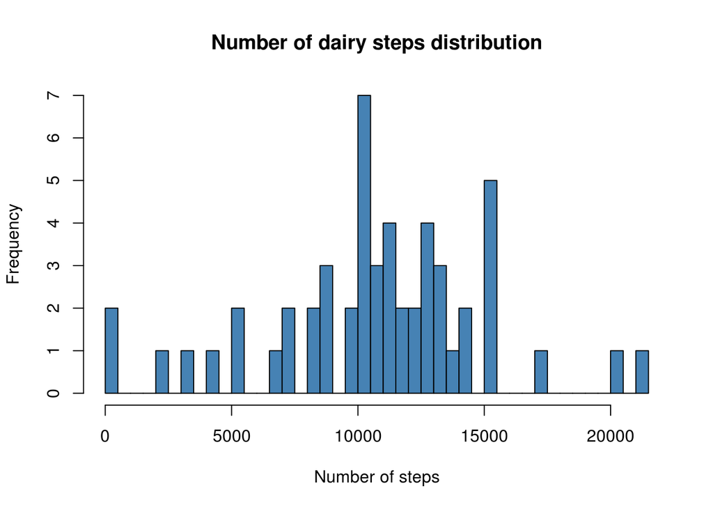

```r
## calculating the total of steps
steps <- with(activity,tapply(steps,date,sum))

## plotting results
hist(steps,breaks = 50,col = "steelblue",
     main = "Number of dairy steps distribution",
     xlab = "Number of steps")
```

### **3. Mean and median of steps for each day**

The next plot shows the mean and median of the number of steps. Means (medians) are shown as red (green) points with respect to left (right) axis.

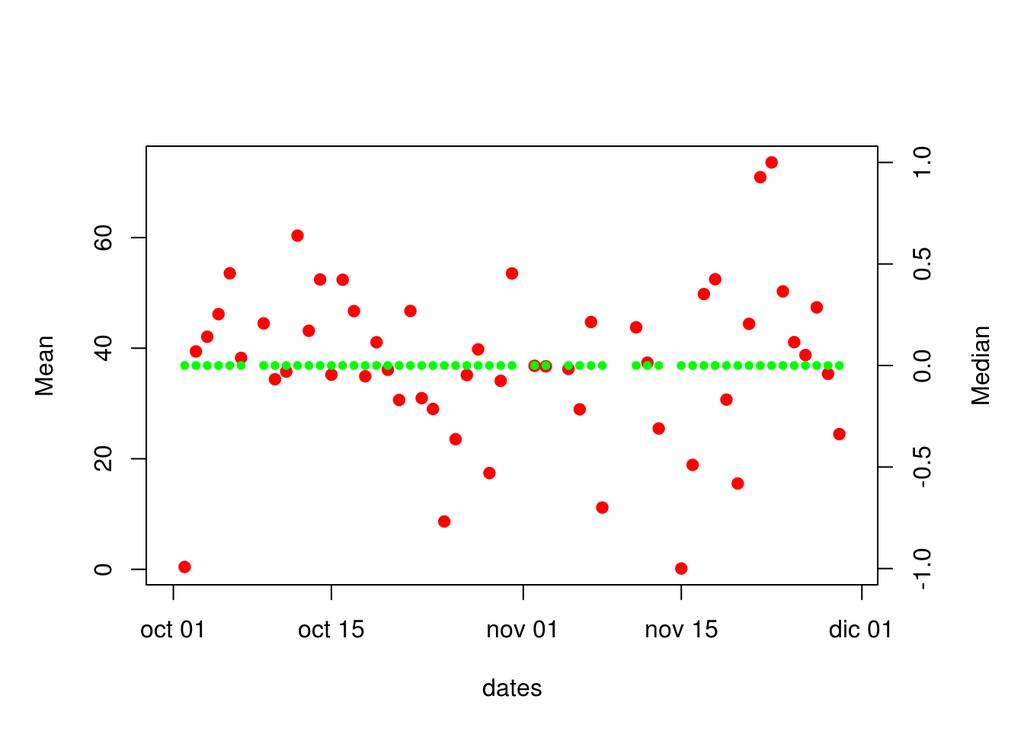

```r
par( mar= c(5,5,5,5))
dates <- unique(activity$date)
means <- with(activity, tapply(steps,date, function(x) mean(x,na.rm = TRUE)))
medians <- with(activity, tapply(steps,date, function(x) median(x,na.rm = TRUE)))
plot(dates,means,pch=19,col="red",ylab = "Mean")
par(new=TRUE)
plot(dates,medians,pch=20,col="green",axes = FALSE,xlab = NA,ylab = NA)
axis(side=4)
mtext(side = 4,line = 3,"Median")
```

From the plot it can be seen that the median are not informative since in the vast majority of time intervals there are zero steps.

### **4. Time series plot of the average number of steps taken**

The next plot shows the time series of the average of steps over time intervals.

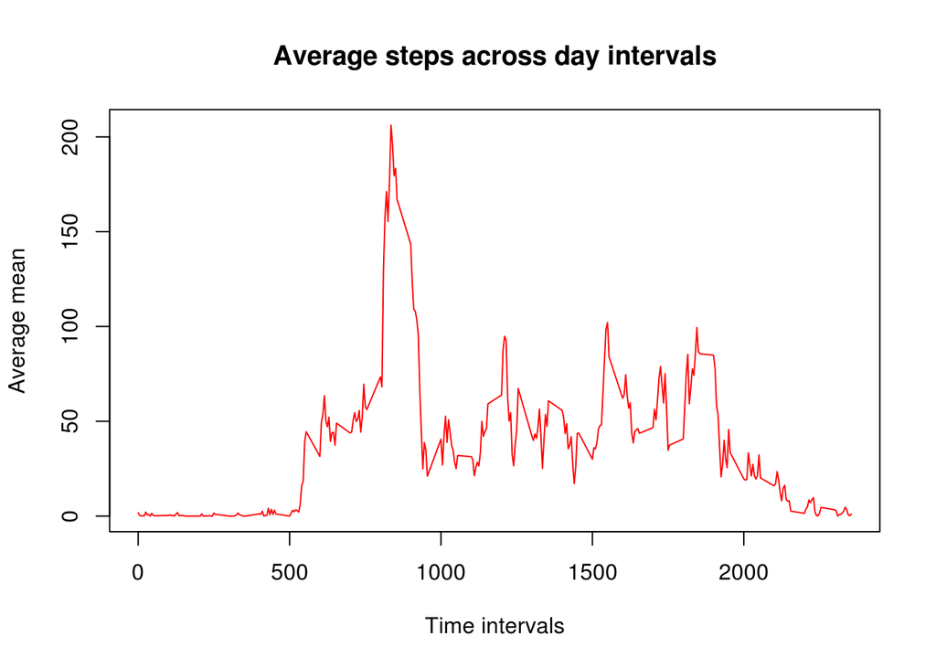

```r
## calculating average mean for intervals
intervals <- unique(activity$interval)
mean.av <- with(activity,tapply(steps, interval,function(x) mean(x,na.rm = TRUE)))

## plotting data
plot(intervals,mean.av,type = "l",col="red",
     main = "Average steps across day intervals",
     ylab = "Average mean",
     xlab = "Time intervals")
```

The plot shows that the more active intervals regarding number of steps is around the ~8.5 hours.

### **5. The 5-minute interval that, on average, contains the maximum number of steps**

```r
maxActivity <- intervals[which(mean.av==max(mean.av))]
maxActivity
```

```
## [1] 835
```

### **6. Code to describe and show a strategy for inputing missing data**

#### **6.1. Calculate and report the total number of missing values in the dataset**

The last entry of the summary applied to the steps column in the data shows the number of NA values as is shown next.

```r
with(activity, summary(steps))
```

```
##    Min. 1st Qu.  Median    Mean 3rd Qu.    Max.    NA's
##    0.00    0.00    0.00   37.38   12.00  806.00    2304
```

The summary shows that there are 2304 NA values in the number of steps data.

#### **6.3. Create a new dataset that is equal to the original dataset but with the missing data filled in**

The inputing method is implemented in the following code.

```r
## method for inputing the data
activity.inputed <- activity
for (i in 1:length(activity$steps)) {
        if ( is.na(activity$steps[i]) ) {
                day <- activity$date[i]
                activity.inputed$steps[i] <- mean(means,na.rm = TRUE)
        }
}
```

The activity.inputed data created in this manner have no missing number steps data as can be shown by using summary().

```r
with(activity.inputed, summary(steps))
```

```
##    Min. 1st Qu.  Median    Mean 3rd Qu.    Max.
##    0.00    0.00    0.00   37.38   37.38  806.00
```

#### **6.4. Make a histogram of the total number of steps taken each day and Calculate and report the mean and median total number of steps taken per day.**

The next code shows the analogous hystogram of the first figure in section 2 but using the inputed data.

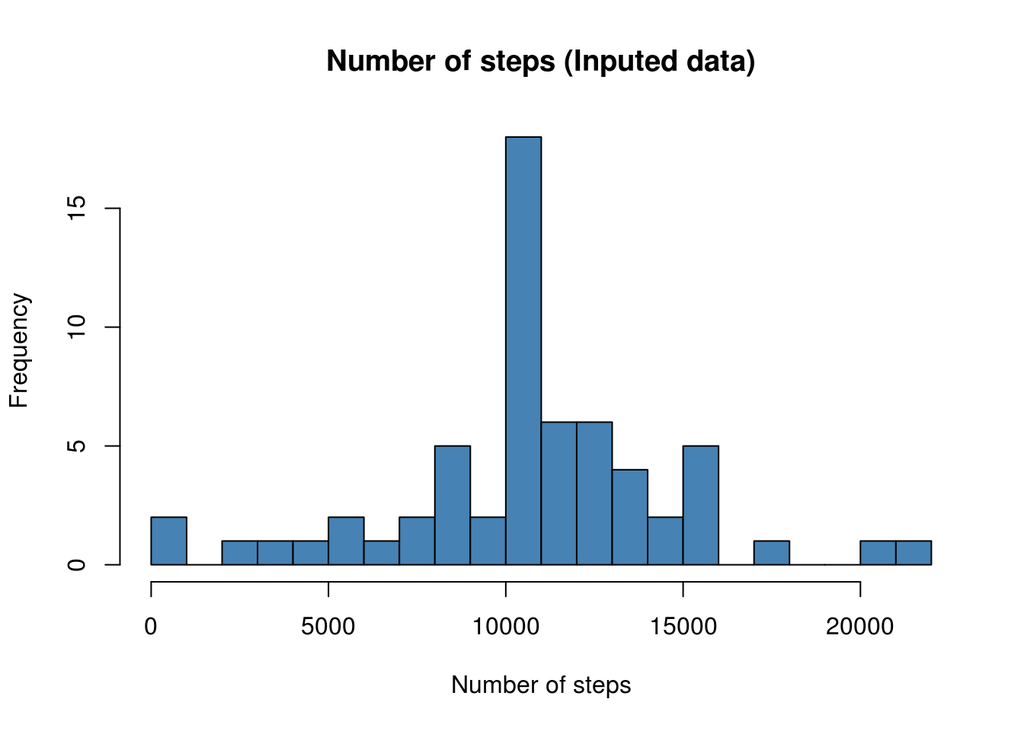

```r
## caluculating total number of steps by day
wDays <- weekdays(activity.inputed$date)
activity.inputed$"weekDays" <- wDays
stepsByDay <- tapply(activity.inputed$steps,activity.inputed$date, function(x)                                                                    sum(x,na.rm = TRUE))

## plotting results
hist(stepsByDay,breaks = 30,col = "steelblue",
     main = "Number of steps (Inputed data)",
     xlab = "Number of steps")
```

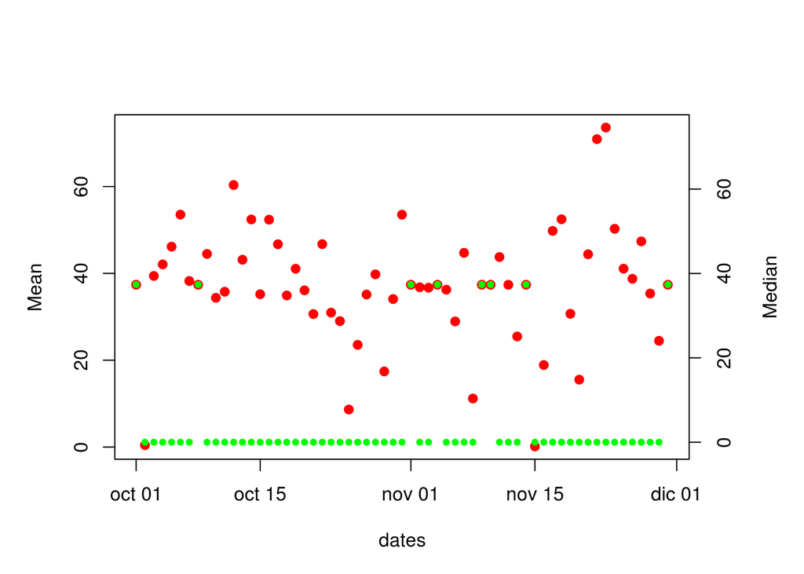

```r
## calculating the mean and median for each day
means.in <- tapply(activity.inputed$steps,activity.inputed$date, function(x)                                                                    mean(x,na.rm = TRUE))
medians.in <- tapply(activity.inputed$steps,activity.inputed$date, function(x)                                                                    median(x,na.rm = TRUE))

## plotting means and medians of inputed data
par(mar=c(5,5,5,5))
plot(dates,means.in,
     pch=19,col="red",ylab = "Mean")
par(new=TRUE)
plot(dates, medians.in,
     pch=20, col="green",
     axes = FALSE, ylim = c(-1,max(means.in)+1),
     xlab = NA, ylab = NA)
axis(side=4)
mtext(side = 4,line = 3,"Median")
```

From the plot it can be seen that medians are still no informative because for each day the majority of the values for intervals is zero steps. Means values now are filled with mean values.

#### **7. Histogram of the total number of steps taken each day after missing values are imputed**

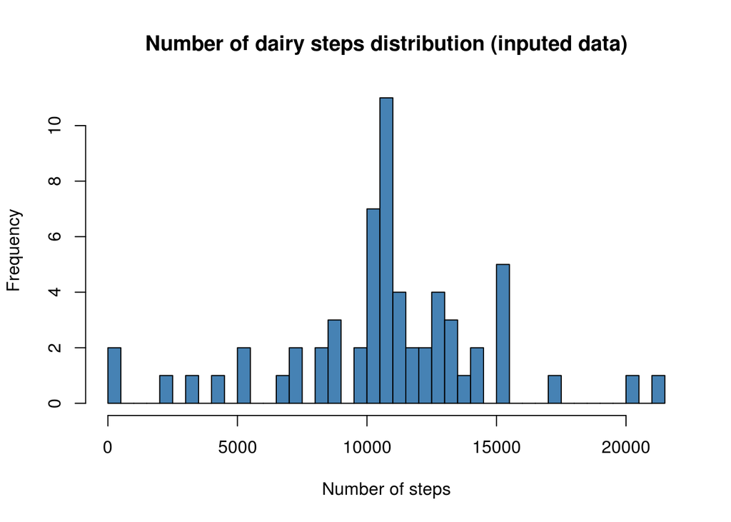

```r
steps <- with(activity.inputed,tapply(steps,date,sum))
hist(steps,breaks = 50,col = "steelblue",
     main = "Number of dairy steps distribution (inputed data)",
     xlab = "Number of steps")
```

### **8. Panel plot comparing the average number of steps taken per 5-minute interval across weekdays and weekends**

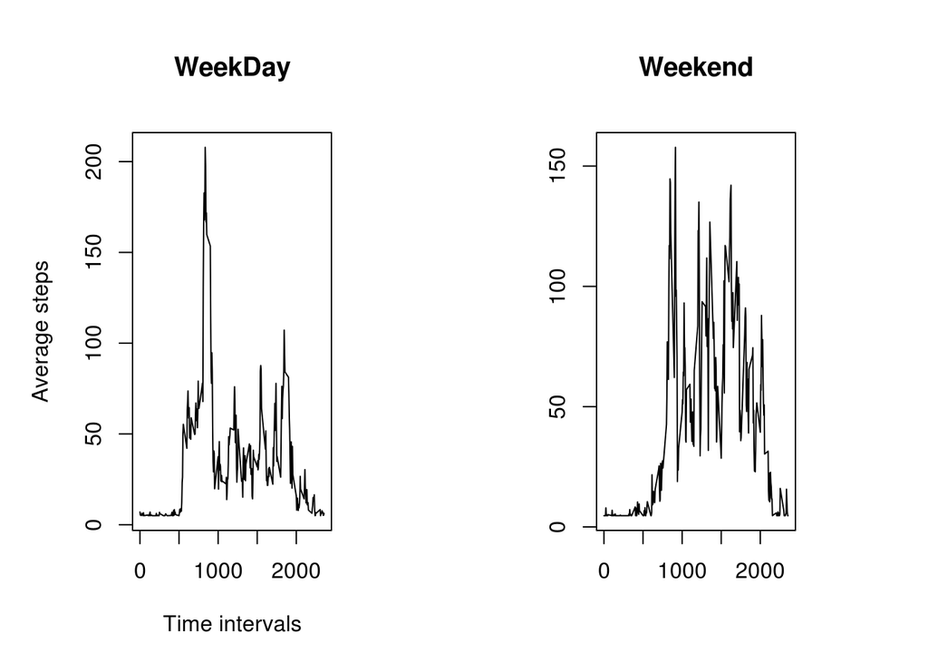

```r
## change days to weekday/weekend tags
activityByWeek <- activity.inputed
wDays <- weekdays(activity.inputed$date)
for (i in 1:length(wDays)) {
        if ( wDays[i] %in% c("sábado","domingo")) {
                wDays[i] <- "weekend"
        } else {
                wDays[i] <- "weekday"
        }
}
activity.inputed$weekDays <- wDays

## calculating the average of steps
activityByWeek <- split(activity.inputed,activity.inputed$weekDays)
activityByWeek <- lapply(activityByWeek,function(x) tapply(x$steps,x$interval, mean))

## plotting the results
par(mfrow=c(1,2))
par(mar=c(5,5,5,5))
plot(intervals,activityByWeek$weekday,
     type = "l",
     col="black",
     main = "WeekDay",
     xlab = "Time intervals",
     ylab = "Average steps")
par(mar=c(5,5,5,5))
plot(intervals,activityByWeek$weekend,
     type = "l",
     col="black",
     main = "Weekend",
     xlab = "",
     ylab = "")
```